# Rank and Nullity

Biostat 216

Author

Dr. Hua Zhou @ UCLA

Published

November 4, 2024

**Highlights**: In this lecture we show some most important results about the rank of a matrix:

1. column rank = row rank = rank.
2. For any $\mathbf{A} \in \mathbb{R}^{m \times n}$, $\text{rank}(\mathbf{A}) \le \min \{m, n\}$.
3. Matrix multiplication can only decrease the rank:  
   $\text{rank}(\mathbf{A} \mathbf{B}) \le \text{rank}(\mathbf{A})$  
   $\text{rank}(\mathbf{A} \mathbf{B}) \le \text{rank}(\mathbf{B})$.  
   Some special cases: (1) $\text{rank}(\mathbf{A} \mathbf{B}) = \text{rank}(\mathbf{A})$ if $\mathbf{B}$ has full row rank. (2) $\text{rank}(\mathbf{A} \mathbf{B}) = \text{rank}(\mathbf{B})$ if $\mathbf{A}$ has full column rank. (3). $\text{rank}(\mathbf{A}' \mathbf{A}) = \text{rank}(\mathbf{A})$ for any $\mathbf{A}$.
4. $\text{rank}(\mathbf{A} + \mathbf{B}) \le \text{rank}(\mathbf{B}) + \text{rank}(\mathbf{B})$.
5. Rank-nullity theorem: For any $\mathbf{A} \in \mathbb{R}^{m \times n}$, $\text{rank}(\mathbf{A}) + \text{nullity}(\mathbf{A}) = n$.
6. Fundamental theorem of ranks: $\text{rank}(\mathbf{A}) = \text{rank}(\mathbf{A}') = \text{rank}(\mathbf{A}'\mathbf{A}) = \text{rank}(\mathbf{A}\mathbf{A}')$.

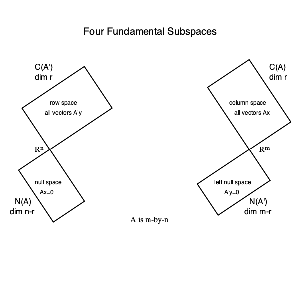

```julia
using Pkg
Pkg.activate(pwd())
Pkg.instantiate()
Pkg.status()
```

```
  Activating project at `~/Documents/github.com/ucla-biostat-216/2023fall/slides/05-rank`
```

```
Status `~/Documents/github.com/ucla-biostat-216/2023fall/slides/05-rank/Project.toml`
  [ce6b1742] RDatasets v0.7.7
  [3eaba693] StatsModels v0.7.3
  [37e2e46d] LinearAlgebra
```

```julia
using LinearAlgebra, RDatasets, StatsModels
```

```julia
# the famous Fisher's Iris data
# <https://en.wikipedia.org/wiki/Iris_flower_data_set>
iris = dataset("datasets", "iris")
```

150×5 DataFrame

125 rows omitted

| Row | SepalLength Float64 | SepalWidth Float64 | PetalLength Float64 | PetalWidth Float64 | Species Cat… |
| --- | --- | --- | --- | --- | --- |
| 1 | 5.1 | 3.5 | 1.4 | 0.2 | setosa |
| 2 | 4.9 | 3.0 | 1.4 | 0.2 | setosa |
| 3 | 4.7 | 3.2 | 1.3 | 0.2 | setosa |
| 4 | 4.6 | 3.1 | 1.5 | 0.2 | setosa |
| 5 | 5.0 | 3.6 | 1.4 | 0.2 | setosa |
| 6 | 5.4 | 3.9 | 1.7 | 0.4 | setosa |
| 7 | 4.6 | 3.4 | 1.4 | 0.3 | setosa |
| 8 | 5.0 | 3.4 | 1.5 | 0.2 | setosa |
| 9 | 4.4 | 2.9 | 1.4 | 0.2 | setosa |
| 10 | 4.9 | 3.1 | 1.5 | 0.1 | setosa |
| 11 | 5.4 | 3.7 | 1.5 | 0.2 | setosa |
| 12 | 4.8 | 3.4 | 1.6 | 0.2 | setosa |
| 13 | 4.8 | 3.0 | 1.4 | 0.1 | setosa |
| ⋮ | ⋮ | ⋮ | ⋮ | ⋮ | ⋮ |
| 139 | 6.0 | 3.0 | 4.8 | 1.8 | virginica |
| 140 | 6.9 | 3.1 | 5.4 | 2.1 | virginica |
| 141 | 6.7 | 3.1 | 5.6 | 2.4 | virginica |
| 142 | 6.9 | 3.1 | 5.1 | 2.3 | virginica |
| 143 | 5.8 | 2.7 | 5.1 | 1.9 | virginica |
| 144 | 6.8 | 3.2 | 5.9 | 2.3 | virginica |
| 145 | 6.7 | 3.3 | 5.7 | 2.5 | virginica |
| 146 | 6.7 | 3.0 | 5.2 | 2.3 | virginica |
| 147 | 6.3 | 2.5 | 5.0 | 1.9 | virginica |
| 148 | 6.5 | 3.0 | 5.2 | 2.0 | virginica |
| 149 | 6.2 | 3.4 | 5.4 | 2.3 | virginica |
| 150 | 5.9 | 3.0 | 5.1 | 1.8 | virginica |

```julia
# use full dummy coding (one-hot coding) for categorical variable Species
X = ModelMatrix(ModelFrame(
    @formula(1 ~ 1 + SepalLength + SepalWidth + PetalLength + PetalWidth + Species),
    iris,
    contrasts = Dict(:Species => StatsModels.FullDummyCoding()))).m
```

```
150×8 Matrix{Float64}:
 1.0  5.1  3.5  1.4  0.2  1.0  0.0  0.0
 1.0  4.9  3.0  1.4  0.2  1.0  0.0  0.0
 1.0  4.7  3.2  1.3  0.2  1.0  0.0  0.0
 1.0  4.6  3.1  1.5  0.2  1.0  0.0  0.0
 1.0  5.0  3.6  1.4  0.2  1.0  0.0  0.0
 1.0  5.4  3.9  1.7  0.4  1.0  0.0  0.0
 1.0  4.6  3.4  1.4  0.3  1.0  0.0  0.0
 1.0  5.0  3.4  1.5  0.2  1.0  0.0  0.0
 1.0  4.4  2.9  1.4  0.2  1.0  0.0  0.0
 1.0  4.9  3.1  1.5  0.1  1.0  0.0  0.0
 1.0  5.4  3.7  1.5  0.2  1.0  0.0  0.0
 1.0  4.8  3.4  1.6  0.2  1.0  0.0  0.0
 1.0  4.8  3.0  1.4  0.1  1.0  0.0  0.0
 ⋮                        ⋮
 1.0  6.0  3.0  4.8  1.8  0.0  0.0  1.0
 1.0  6.9  3.1  5.4  2.1  0.0  0.0  1.0
 1.0  6.7  3.1  5.6  2.4  0.0  0.0  1.0
 1.0  6.9  3.1  5.1  2.3  0.0  0.0  1.0
 1.0  5.8  2.7  5.1  1.9  0.0  0.0  1.0
 1.0  6.8  3.2  5.9  2.3  0.0  0.0  1.0
 1.0  6.7  3.3  5.7  2.5  0.0  0.0  1.0
 1.0  6.7  3.0  5.2  2.3  0.0  0.0  1.0
 1.0  6.3  2.5  5.0  1.9  0.0  0.0  1.0
 1.0  6.5  3.0  5.2  2.0  0.0  0.0  1.0
 1.0  6.2  3.4  5.4  2.3  0.0  0.0  1.0
 1.0  5.9  3.0  5.1  1.8  0.0  0.0  1.0
```

```julia
@show size(X)
@show rank(X)
@show rank(X')
@show rank(X' * X)
@show rank(X * X');
```

```
size(X) = (150, 8)
rank(X) = 7
rank(X') = 7
rank(X' * X) = 7
rank(X * X') = 7
```

```julia
# only one basis vector in N(X)
nullspace(X)
```

```
8×1 Matrix{Float64}:
 -0.4999999999999998
 -9.134970746645288e-17
 -9.988792412695207e-17
 -4.7010048986273254e-17
  3.225202167017096e-16
  0.5000000000000003
  0.5000000000000002
  0.5000000000000001
```

## 1 Rank

Let $\mathbf{A}$ be an $m \times n$ matrix
$$\begin{eqnarray*}
\mathbf{A} = \begin{pmatrix}
\mid & & \mid \\
\mathbf{a}_1 & \ldots & \mathbf{a}_n \\
\mid & & \mid
\end{pmatrix}.
\end{eqnarray*}$$

- The **column rank** of $\mathbf{A}$ is the maximum number of linearly independent columns of $\mathbf{A}$.

  In other words, column rank of $\mathbf{A}$ is $\text{dim}(\mathcal{C}(\mathbf{A}))$.
- The **row rank** of $\mathbf{A}$ is the maximum number of linearly independent rows of $\mathbf{A}$.

  In other words, row rank of $\mathbf{A}$ is $\text{dim}(\mathcal{R}(\mathbf{A})) = \text{dim}(\mathcal{C}(\mathbf{A}'))$.
- For any $m \times n$ matrix $\mathbf{A}$, its column rank is equal to the row rank, which we shall call the **rank** of $\mathbf{A}$.

  We will give two proofs below: one using the fundamental theorem of ranks, the other using rank factorization.
- For any $\mathbf{A} \in \mathbb{R}^{m \times n}$, $\text{rank}(\mathbf{A}) \le \min \{m, n\}$.

```julia
A = [1 -2 -2; 3 -6 -6]
```

```
2×3 Matrix{Int64}:
 1  -2  -2
 3  -6  -6
```

```julia
# column rank
rank(A)
```

```
1
```

```julia
# row rank
rank(A')
```

```
1
```

```julia
# another matrix
@show size(X)
@show rank(X)
```

```
size(X) = (150, 8)
rank(X) = 7
```

```
7
```

- For $\mathbf{A} \in \mathbb{R}^{m \times n}$, we say $\mathbf{A}$ is **full rank** if $\text{rank}(\mathbf{A}) = \min \{m, n\}$.

  It is **full row rank** if $\text{rank}(\mathbf{A}) = m$.

  It is **full column rank** if $\text{rank}(\mathbf{A}) = n$.
- A square matrix $\mathbf{A} \in \mathbb{R}^{n \times n}$ is **singular** if $\text{rank}(\mathbf{A}) < n$ and **non-singular** (or **invertible**) if $\text{rank}(\mathbf{A}) = n$.
- Example: The identity matrix
  $$\mathbf{I} = \begin{pmatrix}
  1 & \cdots & 0 \\
  \vdots & \ddots & \vdots \\
  0 & \cdots & 1
  \end{pmatrix}$$
  is full rank.

## 2 Effects of matrix multiplication on rank

- $\text{rank}(\mathbf{A}\mathbf{B}) \le \text{rank}(\mathbf{A})$ and $\text{rank}(\mathbf{A}\mathbf{B}) \le \text{rank}(\mathbf{B})$.

  In words, **matrix multiplication can only decrease the rank**.

  Proof: Because $\mathcal{C}(\mathbf{A}\mathbf{B}) \subseteq \mathcal{C}(\mathbf{A})$ (why?), we have $\text{rank}(\mathbf{A}\mathbf{B}) \le \text{rank}(\mathbf{A})$ by monotonicity of dimension. Similary, because the row space of $\mathbf{A}\mathbf{B}$ is a subset of the row space of $\mathbf{B}$, we have $\text{rank}(\mathbf{A}\mathbf{B}) \le \text{rank}(\mathbf{B})$.
- $\text{rank}(\mathbf{A}\mathbf{B}) = \text{rank}(\mathbf{A})$ if $\mathbf{B}$ is square and of full rank. More general, **left-multiplying by a matrix with full column rank or right-multiplying by a matrix of full row rank does not change rank**.

  Proof (optional): We show the more general statement. Assume $\mathbf{B} \in \mathbb{R}^{m \times n}$ has full row rank, we want to show $\text{rank}(\mathbf{A}) = \text{rank}(\mathbf{A}\mathbf{B})$. Since $\mathbf{B} \in \mathbb{R}^{m \times n}$ has full row rank, there exists a permutation matrix $\mathbf{P} \in \{0,1\}^{n \times n}$ such that
  $$\mathbf{B} \mathbf{P} = \begin{pmatrix} \mathbf{B}_1 : \mathbf{B}_2 \end{pmatrix},$$
  where $\mathbf{B}_1 \in \mathbb{R}^{m \times m}$ is non-singular and $\mathbf{B}_2 \in \mathbb{R}^{m \times (n-m)}$. Then
  $$\text{rank}(\mathbf{A}) \ge \text{rank}(\mathbf{A}\mathbf{B}) = \text{rank}(\mathbf{A} \begin{pmatrix} \mathbf{B}_1 : \mathbf{B}_2 \end{pmatrix} \mathbf{P}') \ge \text{rank} \left( \mathbf{A} \begin{pmatrix} \mathbf{B}_1 : \mathbf{B}_2 \end{pmatrix} \mathbf{P}' \mathbf{P} \begin{pmatrix} \mathbf{B}_1^{-1} \\ \mathbf{O} \end{pmatrix} \right) = \text{rank} (\mathbf{A} \mathbf{I}_m) = \text{rank} (\mathbf{A}).$$
  Thus $\text{rank}(\mathbf{A}) = \text{rank} (\mathbf{A} \mathbf{B})$. Proof for the other half of the statement follows the same argument.
- Example: 2019 qual. exam Q1.

```julia
A = [1 -2 -2; 3 -6 -6]
```

```
2×3 Matrix{Int64}:
 1  -2  -2
 3  -6  -6
```

```julia
rank(A)
```

```
1
```

```julia
# this B does not have full row rank
B = [2 2; 1 0; 0 1]
```

```
3×2 Matrix{Int64}:
 2  2
 1  0
 0  1
```

```julia
rank(A * B)
```

```
0
```

```julia
# B has full row rank
B = [2 2 0; 1 0 0; 0 1 1]
```

```
3×3 Matrix{Int64}:
 2  2  0
 1  0  0
 0  1  1
```

```julia
# A * B preserves rank of A
rank(A * B)
```

```
1
```

## 3 Rank-nullity theorem

- The **nullity** of a matrix $\mathbf{A}$ is the dimension of its null space
  $$\text{nullity}(\mathbf{A}) = \text{dim}(\mathcal{N}(\mathbf{A})).$$
- Let $\mathbf{A} \in \mathbb{R}^{m \times n}$, then
  $$\text{rank}(\mathbf{A}) + \text{nullity}(\mathbf{A}) = n.$$

  Proof (optional): Denote $\nu = \text{nullity}(\mathbf{A}) = \text{dim}(\mathcal{N}(\mathbf{A}))$. Let $\mathbf{X} \in \mathbb{R}^{n \times n}$ be
  $$\mathbf{X} = \begin{pmatrix} \mathbf{X}_1 : \mathbf{X}_2 \end{pmatrix},$$
  where columns of $\mathbf{X}_1 \in \mathbb{R}^{n \times \nu}$ form a basis of $\mathcal{N}(\mathbf{A})$ and columns of $\mathbf{X}_2 \in \mathbb{R}^{n \times (n - \nu)}$ extend those in $\mathbf{X}_1$ to be a basis of $\mathbb{R}^n$. We show columns of $\mathbf{A} \mathbf{X}_2$ form a basis of $\mathcal{C}(\mathbf{A})$. Thus $\text{rank}(\mathbf{A}) = \text{dim}(\mathcal{C}(\mathbf{A})) = n - \nu$.
  1. To show that columns of $\mathbf{A} \mathbf{X}_2$ are linearly independent. Assume $\mathbf{A} \mathbf{X}_2 \mathbf{v} = \mathbf{0}$. Then $\mathbf{X}_2 \mathbf{v} \in \mathcal{N}(\mathbf{A}) = \mathcal{C}(\mathbf{X}_1)$. Thus $\mathbf{X}_2 \mathbf{v} = \mathbf{X}_1 \mathbf{u}$ for some $\mathbf{u}$, or equivalently,
     $$\begin{pmatrix} \mathbf{X}_1 : \mathbf{X}_2 \end{pmatrix} \begin{pmatrix} -\mathbf{u} \\ \mathbf{v} \end{pmatrix} = \mathbf{0}_n.$$
     Since the matrix $\begin{pmatrix} \mathbf{X}_1 : \mathbf{X}_2 \end{pmatrix}$ is non-singular, we must have $\mathbf{u}=\mathbf{0}$ and $\mathbf{v}=\mathbf{0}$. This shows that $\mathbf{v}=\mathbf{0}$ whenever $\mathbf{A} \mathbf{X}_2 \mathbf{v} = \mathbf{0}$. So the columns of $\mathbf{A} \mathbf{X}_2$ are linearly independent.
  2. Next we show the columns of $\mathbf{A} \mathbf{X}_2$ span $\mathcal{C}(\mathbf{A})$ by showing $\mathcal{C}(\mathbf{A}) \subseteq \mathcal{C}(\mathbf{A} \mathbf{X}_2)$. Let $\mathbf{w} \in \mathcal{C}(\mathbf{A})$. Then $\mathbf{w} = \mathbf{A} \mathbf{y}$ for some vector $\mathbf{y}$. Because $\mathbf{y} \in \mathbb{R}^n$, which is spanned by columns of $\mathbf{X}$, we can write $\mathbf{y} = \mathbf{X}_1 \mathbf{z}_1 + \mathbf{X}_2 \mathbf{z}_2$ for some vectors $\mathbf{z}_1$ and $\mathbf{z}_2$. Thus $\mathbf{w} = \mathbf{A} \mathbf{X}_1 \mathbf{z}_1 + \mathbf{A} \mathbf{X}_2 \mathbf{z}_2 = \mathbf{A} \mathbf{X}_2 \mathbf{z}_2 \in \mathcal{C}(\mathbf{A} \mathbf{X}_2)$. This proves $\mathcal{C}(\mathbf{A}) \subseteq \mathcal{C}(\mathbf{A} \mathbf{X}_2)$.

```julia
A = [1 -2 -2; 3 -6 -6]
```

```
2×3 Matrix{Int64}:
 1  -2  -2
 3  -6  -6
```

```julia
rank(A)
```

```
1
```

```julia
nullity = size(nullspace(A), 2)
```

```
2
```

## 4 Fundamental theorem of ranks (important)

- $\text{rank}(\mathbf{A}) = \text{rank}(\mathbf{A}') = \text{rank}(\mathbf{A}'\mathbf{A}) = \text{rank}(\mathbf{A}\mathbf{A}')$.

  Proof: Early on we showed $\mathcal{N}(\mathbf{A}'\mathbf{A}) = \mathcal{N}(\mathbf{A})$. Thus $\text{nullity}(\mathbf{A}'\mathbf{A}) = \text{nullity}(\mathbf{A})$. Then by the rank-nullity theorem, $\text{rank}(\mathbf{A}'\mathbf{A}) = n - \text{nullity}(\mathbf{A}'\mathbf{A}) = n - \text{nullity}(\mathbf{A}) = \text{rank}(\mathbf{A})$.

  Transposition gives $\text{rank}(\mathbf{A}\mathbf{A}') = \text{rank}(\mathbf{A}')$.

  Finally, $\text{rank}(\mathbf{A}) = \text{rank}(\mathbf{A}'\mathbf{A}) \le \text{rank}(\mathbf{A}') = \text{rank}(\mathbf{A}\mathbf{A}') \le \text{rank}(\mathbf{A})$, indicating $\text{rank}(\mathbf{A}) = \text{rank}(\mathbf{A}') = \text{rank}(\mathbf{A}'\mathbf{A}) = \text{rank}(\mathbf{A}\mathbf{A}')$.
- Matrices of form $\mathbf{A}'\mathbf{A}$ or $\mathbf{A}\mathbf{A}'$ are called the **Gram matrix** or **Gramian matrix**.

```julia
A = [1 -2 -2; 3 -6 -6]
```

```
2×3 Matrix{Int64}:
 1  -2  -2
 3  -6  -6
```

```julia
rank(A)
```

```
1
```

```julia
A'A
```

```
3×3 Matrix{Int64}:
  10  -20  -20
 -20   40   40
 -20   40   40
```

```julia
rank(A'A)
```

```
1
```

```julia
A * A'
```

```
2×2 Matrix{Int64}:
  9  27
 27  81
```

```julia
rank(A * A')
```

```
1
```

## 5 Rank factorization (important)

- Let $\mathbf{A} \in \mathbb{R}^{m \times n}$ with (column) rank $r \ge 1$. The product $\mathbf{A} = \mathbf{C} \mathbf{R}$, where $\mathbf{C} \in \mathbb{R}^{m \times r}$ and $\mathbf{R} \in \mathbb{R}^{r \times n}$ is called a **rank decomposition** or **rank factorization** of $\mathbf{A}$.
- Visualize (TODO):
  $$\mathbf{A} = \begin{pmatrix}
  | & & | \\
  \mathbf{c}_1 & \cdots & \mathbf{c}_r \\
  | & & |
  \end{pmatrix} \begin{pmatrix} - & \mathbf{r}_1' & - \\
  & \vdots & \\ - & \mathbf{r}_r' & -
  \end{pmatrix}.$$
- **Existence of rank factorization.** Any non-null matrix has a rank decomposition. To construct one, let columns of
  $$\begin{eqnarray*}
  \mathbf{C} = \begin{pmatrix}
  \mid & & \mid \\
  \mathbf{c}_1 & \cdots & \mathbf{c}_r \\
  \mid & & \mid
  \end{pmatrix}
  \end{eqnarray*}$$
  be a basis of $\mathcal{C}(\mathbf{A})$. Then $\mathcal{C}(\mathbf{A}) \subseteq \mathcal{C}(\mathbf{C})$. Thus there exists $\mathbf{R}$ such that $\mathbf{A} = \mathbf{C} \mathbf{R}$.
- Is rank factorization unique? No. $\mathbf{A} = \mathbf{C} \mathbf{R} = (\mathbf{C} \mathbf{M}) (\mathbf{M}^{-1} \mathbf{R})$ for any non-singular matrix $\mathbf{M}^{r \times r}$.
- Suppose $\mathbf{A}$ has column rank $r > 0$ and rank factorization $\mathbf{A} = \mathbf{C} \mathbf{R}$. Then
  $$\begin{eqnarray*}
  & & \text{row rank of } \mathbf{A} \\
  &=& \text{column rank of } \mathbf{A}' \\
  &=& \text{column rank of } \mathbf{R}' \mathbf{C}' \\
  &\le& \text{column rank of } \mathbf{R}' \quad \quad (\text{right matrix multiplication shrinks column space}) \\
  &\le& r \\
  &=& \text{column rank of } \mathbf{A}.
  \end{eqnarray*}$$
  Now applying the above conclusion to matrix $\mathbf{A}'$, we have
  $$\text{row rank of } \mathbf{A}' \le \text{column rank of } \mathbf{A}',$$
  i.e.,
  $$\text{column rank of } \mathbf{A} \le \text{row rank of } \mathbf{A}.$$
  Thus we have another proof of the famous result $\text{rank}(\mathbf{A}) = \text{rank}(\mathbf{A}')$.
- Let $\text{rank}(\mathbf{A}) = r$ and $\mathbf{A} = \mathbf{C} \mathbf{R}$ be a rank factorization. Then
  1. $\text{rank}(\mathbf{C}) = \text{rank}(\mathbf{R}) = r$,
  2. $\mathcal{C}(\mathbf{A}) = \mathcal{C}(\mathbf{C})$, $\mathcal{C}(\mathbf{A}') = \mathcal{C}(\mathbf{R}')$ and $\mathcal{N}(\mathbf{A}) = \mathcal{N}(\mathbf{R})$.

  Proof of 1: $r = \text{rank}(\mathbf{A}) = \text{rank}(\mathbf{C}\mathbf{R}) \le \text{rank}(\mathbf{C}) \le r$. Thus $\text{rank}(\mathbf{C}) = r$. Similarly $\text{rank}(\mathbf{R}) = r$.
  Proof of 2 (optional): $\mathcal{C}(\mathbf{A}) \subseteq \mathcal{C}(\mathbf{C})$ is trivial. Suppose $\mathcal{C}(\mathbf{C})$ is strictly larger than $\mathcal{C}(\mathbf{A})$. Then there exists vector $\mathbf{v} \in \mathcal{C}(\mathbf{C})$ that is not a linear combination of columns of $\mathbf{A}$. Let $\mathbf{u}_1, \ldots, \mathbf{u}_r$ be a basis of $\mathcal{C}(\mathbf{A})$. Then the $r+1$ vectors $\mathbf{u}_1, \ldots, \mathbf{u}_r, \mathbf{v}$ is an independent set in $\mathcal{C}(\mathbf{C})$, contadicting the fact $\text{rank}(\mathbf{C}) = r$. Therefore we must have $\mathcal{C}(\mathbf{A}) = \mathcal{C}(\mathbf{C})$. Similar argument shows $\mathcal{C}(\mathbf{A}') = \mathcal{C}(\mathbf{R}')$.
  To show $\mathcal{N}(\mathbf{A}) = \mathcal{N}(\mathbf{R})$, one direction $\mathcal{N}(\mathbf{A}) \supseteq \mathcal{N}(\mathbf{R})$ is trivial (why?). To show the other direction,
  $$\begin{eqnarray*}
  & & \mathbf{x} \in \mathcal{N}(\mathbf{A}) \\
  &\Rightarrow& \mathbf{A} \mathbf{x} = \mathbf{0} \\
  &\Rightarrow& \mathbf{C} \mathbf{R} \mathbf{x} = \mathbf{0} \\
  &\Rightarrow& \mathbf{R} \mathbf{x} \in \mathcal{N}(\mathbf{C}).
  \end{eqnarray*}$$
  But by the rank-nullity theorem, $\text{nullity}(\mathbf{C}) = r - \text{rank}(\mathbf{C}) = 0$. Thus $\mathbf{R} \mathbf{x} = \mathbf{0}$, that is $\mathbf{x} \in \mathcal{N}(\mathbf{R})$. We have shown $\mathcal{N}(\mathbf{A}) \subseteq \mathcal{N}(\mathbf{R})$.

```julia
A = [1 -2 -2; 3 -6 -6]
```

```
2×3 Matrix{Int64}:
 1  -2  -2
 3  -6  -6
```

```julia
C = [1; 3]
```

```
2-element Vector{Int64}:
 1
 3
```

```julia
R = [1 -2 -2]
```

```
1×3 Matrix{Int64}:
 1  -2  -2
```

```julia
C * R
```

```
2×3 Matrix{Int64}:
 1  -2  -2
 3  -6  -6
```